# segmento-de-reta

#### $$ \text{---\{ Proporcionalidades \}---} \\[24pt] $$

## $$ \text{Segmento de Retas} $$

$$ \text{Prof. Eduardo Ono} \\[24pt] $$

**Sumário**

- 1. Conceitos
- 1. Segmento de Reta
  - 2.1. Definição
  - 2.2. Segmentos consecutivos
  - 2.3. Segmentos colineares
  - 2.4. Segmentos adjacentes
  - 2.5. Congruência de segmentos
  - 2.6. Comparação de segmentos
  - 2.7. Adição de segmentos
  - 2.8. Medida de um segmento - comprimento
  - 2.9. Ponto médio de um segmento
    - 2.9.1. Definição
  - 2.10. Distância entre dois pontos
    - 2.10.1. Distância geométrica
    - 2.10.2. Distância métrica

# 1. Conceitos

A noção de "estar entre" é uma noção primitiva que obedece aos seguintes postuladois (ou axiomas):

Quaisquer que sejam os pontos $A$, $B$ e $P$:

1. Se $P$ está entre $A$ e $B$, então $A$, $B$ e $P$ são colineares;
2. Se $P$ está entre $A$ e $B$, então $A$, $B$ e $P$ são distintos dois a dois;
3. Se $P$ está entre $A$ e $B$, então $A$ não está entre $P$ e $B$ nem $B$ está entre $A$ e $P$;
4. Quaisquer que sejam os pontos $A$ e $B$, se $A$ é distinto de $B$, então existe um ponto $P$ que está entre $A$ e $B$.

# 2. Segmento de Reta

## 2.1. Definição

Dados dois pontos distintos, um **segmento de reta** é a reunião do conjunto desses dois pontos com o conjunto dos pontos que estão entre eles.

Assim, dados os pontos $A$ e $B$, $\,A \neq B\,$, o segmento de reta $AB$ (indicado por $\overline{AB}$) é:

$$ \overline{AB} = \{A, B\} \cup \{X \ | \ X \text{ está entre $A$ e $B$}\}. $$

Os pontos $A$ e $B$ são também chamados de extremidades do segmento $\overline{AB}$.

## 2.2. Segmentos consecutivos

Dois segmentos de reta são **consecutivos** se, e somente se, uma extremidade de um deles é também extremidade do outro, ou seja, uma extremidade de um segmento coincide com uma extremidade do outro segmento.

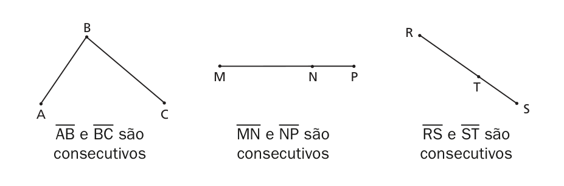

Fonte: Iezzi

## 2.3. Segmentos colineares

Dois segmentos de reta são **colineares** se, e somente se, estão *contidos* numa mesma reta.

## 2.4. Segmentos adjacentes

Dois segmentos consecutivos e colineares são **adjacentes** se, e somente se, possuem em comum apenas uma extremidade, ou seja, não têm pontos internos comuns.

## 2.5. Congruência de segmentos

A congruência (símbolo: $\equiv$) de segmentos é uma noção primitiva que satisfaz os seguintes postulados:

1. Reflexiva. Todo segmento é congruente a si mesmo: $\ \overline{AB} \equiv \overline{AB}\,$.
2. Simétrica. Se $\ \overline{AB} \equiv \overline{CD}\,$, então $\ \overline{CD} \equiv \overline{AB}\,$.
3. Transitiva. Se $\ \overline{AB} \equiv \overline{CD}\ $ e $\ \overline{CD} \equiv \overline{EF}\,$, então $\ \overline{AB} \equiv \overline{EF}\,$.
4. Transporte de segmentos. Dados um segmento $\overline{AB}$ e uma semirreta de origem $A'$, existe sobre esta semirreta um único ponto $B'$ tal que $\,\overline{A'B'}\,$ seja congruente a $\,\overline{AB}\,$.

## 2.6. Comparação de segmentos

Dados dois segmentos, $\,\overline{AB}\,$ e $\,\overline{CD}\,$, pelo postulado do transporte, podemos obter na semirreta $\,\overrightarrow{AB}\,$ um ponto $P$ tal que $\,\overline{AP} \equiv \overline{CD}\,$. Temos três hipóteses a considerar:

1. O ponto $P$ está entre $A$ e $B$. Neste caso, dizemos que $\overline{AB}$ é **maior** que $\,\overline{CD}\,$ ($\overline{AB} > \overline{CD}$).
2. O ponto $P$ coincide com $B$, caso em que $\,\overline{AB}\,$ é **congruente** a $\,\overline{CD}\,$ ($\overline{AB} \equiv \overline{CD}$).
3. O ponto $B$ está entre $A$ e $P$. Neste caso, dizemos que $\,\overline{AB}\,$ é menor que $\,\overline{CD}\,$ ($\overline{AB} < \overline{CD}$).

## 2.7. Adição de segmentos

Dados dois segmentos $\,\overline{AB}\,$ e $\,\overline{CD}\,$, tomando-se numa semirreta qualquer de origem $O$ os segmentos adjacentes $\,\overline{OP}\,$ e $\,\overline{PQ}\,$ tais que

$$ \overline{OP} \equiv \overline{AB} \quad\text{e}\quad \overline{PQ} \equiv \overline{CD} $$

dizemos que o segmento $\,\overline{OQ}\,$ é a soma de $\,\overline{OP}\,$ com $\,\overline{PQ}\,$, ou seja,

$$ \overline{OQ} = \overline{OP} + \overline{PQ} $$

Também é a soma de $\,\overline{AB}\,$ com $\,\overline{CD}\,$, ou seja,

$$ \overline{OQ} = \overline{AB} + \overline{CD}\,. $$

Se $\,\overline{OP}\,$ é a soma de $n$ segmentos congruentes a $\,\overline{AB}\,$, $\,\overline{OP}\,$ é múltiplo de $\,\overline{AB}\,$ segundo o fator $n$:

$$ \overline{OP} = n \cdot \overline{AB}\,. $$

Nesse caso, dizemos também que $\,\overline{AB}\,$ é submúltiplo de $\,\overline{OP}\,$ segundo $n$.

## 2.8. Medida de um segmento - comprimento

A medida de um segmento (não nulo) $\,\overline{AB}\,$, indicado por $\,m(\overline{AB})\,$ ou simplesmente por $\,AB\,$, é um número real positivo associado ao segmento de forma tal que:

1. Segmentos congruentes têm medidas iguais e, reciprocamente, segmentos que têm medidas iguais são congruentes:

$$ \overline{AB} \equiv \overline{CD} \iff m(\overline{AB}) = m(\overline{CD}) $$

1. Se um segmento é maior que outro, sua medida é maior que a deste outro:

$$\overline{AB} > \overline{CD} \iff m(\overline{AB}) > m(\overline{CD}) $$

1. A um **segmento soma** está associada uma medida que é a soma das medidas dos segmentos parcelas: $$ \overline{OP} = \overline{AB} + \overline{CD} \iff m(\overline{OP}) = m(\overline{AB}) + m(\overline{CD}) $$

À medida de um segmento dá-se o nome de comprimento do segmento.

Em geral, associa-se um número (medida) a um segmento estabelecendo a razão (quociente) entre este segmento e outro segmento tomado como unidade. O segmento unitário no Sistema Internacional de Unidades (SI) é o metro (símbolo: m).

## 2.9. Ponto médio de um segmento

### 2.9.1. Definição

Um ponto $M$ é **ponto médio** do segmento $\,\overline{AB}\,$ se, e somente se, $M$ está entre $A$ e $B$ e $\,\overline{AM} \equiv \overline{MB}\,$:

$$ M \in \overline{AB} \quad\text{e}\quad \overline{AM} \equiv \overline{MB}\,. $$

## 2.10. Distância entre dois pontos

### 2.10.1. Distância geométrica

Dados dois pontos distintos, $A$ e $B$, a distância entre $A$ e $B$ (indicada por $d_{A, B}$) é o segmento $\,\overline{AB}\,$ ou qualquer segmento congruente a $\,\overline{AB}\,$.

### 2.10.2. Distância métrica

Dados dois pontos distintos, $A$ e $B$, a distância entre $A$ e $B$ é a medida (comprimento) do segmento $\,\overline{AB}\,$.

Se $A$ e $B$ coincidem, dizemos que a distância geométrica entre $A$ e $B$ é nula e a distância métrica é igual a zero.